# Startup Failure Analysis

Reproducible Phase-2 report: predicting how long startups survive, and why

## Introduction

Every number and chart below is computed live when this document renders — nothing is pasted in from a prior run. The same random seed (`RANDOM_STATE = 42`) is used everywhere a model or split needs one, so re-rendering this document reproduces identical results.

```python
import sys
from pathlib import Path

PROJECT_ROOT = Path("..").resolve()
sys.path.insert(0, str(PROJECT_ROOT))

import pandas as pd
from IPython.display import Image, display

pd.set_option("display.max_columns", None)
```

## The Data

```python
from feature_pipeline import build_dataset, RANDOM_STATE, COMMON_FLAGS

df = build_dataset()
print(f"Rows: {len(df)}")
print(f"Random seed used throughout: {RANDOM_STATE}")
df[["Name", "Sector", "duration_years", "raised_musd", "duration_class"]].head()
```

```
Rows: 409
Random seed used throughout: 42
```

|  | Name | Sector | duration_years | raised_musd | duration_class |
| --- | --- | --- | --- | --- | --- |
| 0 | Avant | Finance and Insurance | 11 | 655.0 | long_run |
| 1 | Bitpass | Finance and Insurance | 6 | 2.0 | typical |
| 2 | Cake Financial | Finance and Insurance | 5 | 3.0 | early |
| 3 | Circle | Finance and Insurance | 10 | 500.0 | typical |
| 4 | Clarity Money | Finance and Insurance | 6 | 11.0 | typical |

```python
import matplotlib
matplotlib.use("Agg")
import matplotlib.pyplot as plt

fig, axes = plt.subplots(1, 2, figsize=(11, 4))

df["Sector"].value_counts().plot(kind="barh", ax=axes[0], color="steelblue")
axes[0].set_title("Companies per sector")
axes[0].set_xlabel("count")

df["duration_years"].plot(kind="hist", bins=18, ax=axes[1], color="darkorange")
axes[1].set_title("Years of operation before failing")
axes[1].set_xlabel("years")

plt.tight_layout()
plt.show()
```

[output not shown]

The dataset spans 6 sectors (Information is the largest, Food/services the smallest at only 26 rows) and 9 tagged failure reasons (Giants, No Budget, Competition, Poor Market Fit, Acquisition Stagnation, Monetization Failure, Niche Limits, Execution Flaws, Trend Shifts). Duration is right-skewed: most startups fail within 5–10 years, with a long tail out to 18 years.

### Data quality, honestly

The raw data has real quirks that shape every decision below (full detail in `data_notes.md`):

- **Two different date formats** across source files (`"YYYY-YYYY"` vs. `"N (YYYY-YYYY)"`) — resolved by always computing duration as `end_year − start_year`.
- **`How Much They Raised` is dirty in 5–17% of rows** per sector — estimates, parenthetical acquirer amounts, compound figures. The leading `$<number>` is extracted; ambiguous rows are flagged, not silently trusted.
- **The failure-reason flags are hindsight labels** — assigned after each company’s fate was already known. This matters a lot for what this model can and can’t be used for (see Business interpretation).
- **The “master” list of 815 startups is not a superset of the 6 enriched sector files** — for Health Care and Manufacturing specifically, most enriched rows don’t even appear in the master list. The two are treated as independently compiled, not joined.

## A Leakage-Safe Feature Pipeline

Every model below shares one `scikit-learn` `Pipeline`, so preprocessing (imputation, scaling, one-hot encoding) is always fit on the training split only — never on data the model will later be scored on.

```python
from feature_pipeline import build_pipeline, FundingFeatureEngineer

print(FundingFeatureEngineer.__doc__)
```

```
Fits sector-median funding statistics on training data only, then uses
them to (a) impute the residual missing raised_musd values and (b) derive
log / squared-log / sector-relative funding features. Fitting only on the
split passed to .fit() is what keeps this leakage-safe.
```

The one exception is intentional and explained in the docstring above: sector-median funding statistics are fit fresh on whatever split is passed to `.fit()` — so during evaluation they see only the training rows, and during final model export (used by the live app) they see the full dataset, on purpose, since a deployed model should use every bit of available signal.

## Regression Ladder: How Many Years Will It Survive?

Four models, from a naive guess up to a tuned gradient-boosted tree, all scored on the same held-out 20% test split.

```python
import regression_ladder

regression_ladder.main()
```

```
DecisionTreeRegressor best max_depth by CV R2: 2 (train R2=0.415, CV R2=0.332)
XGBRegressor best params: {'model__colsample_bytree': np.float64(0.8703100983459974), 'model__learning_rate': np.float64(0.01908085481211199), 'model__max_depth': 3, 'model__n_estimators': 267, 'model__subsample': np.float64(0.8349262400109296)}
XGBRegressor best CV R2: 0.348

=== Regression Leaderboard ===
       model  train_R2   test_R2  test_MAE  test_RMSE   R2_gap
DecisionTree  0.409782  0.377406  2.233481   2.722067 0.032376
     XGBoost  0.707268  0.366120  2.230457   2.746628 0.341148
     LassoCV  0.442862  0.362124  2.235049   2.755272 0.080738
       Dummy  0.000000 -0.001348  2.897292   3.452143 0.001348
DecisionTree: +0.379 test R2 over Dummy baseline (notable)
XGBoost: +0.367 test R2 over Dummy baseline (notable)
LassoCV: +0.363 test R2 over Dummy baseline (notable)

Top LassoCV coefficients (regression):
cat__decade_started_2010s_plus   -2.801365
num__log_raised_musd              1.106343
bin__single_cause_failure        -0.989951
cat__decade_started_2000s         0.789675
bin__Poor Market Fit             -0.701575
bin__Giants                       0.536362
cat__Sector_Manufacturing        -0.530259
num__n_flags_sq                  -0.424524
bin__big_tech_pressure            0.308710
bin__No Budget                   -0.248864
dtype: float64

Top XGBoost permutation importances (regression, raw input columns):
decade_started          0.451816
raised_musd             0.236141
Sector                  0.037267
No Budget               0.014393
Poor Market Fit         0.013040
Trend Shifts            0.007298
big_tech_pressure       0.005120
Competition             0.003035
Execution Flaws         0.001494
Monetization Failure    0.001009
dtype: float64
```

```python
display(Image(filename=str(PROJECT_ROOT / "modeling_output" / "regression_tree_validation_curve.png")))
display(Image(filename=str(PROJECT_ROOT / "modeling_output" / "regression_predicted_vs_actual.png")))
```

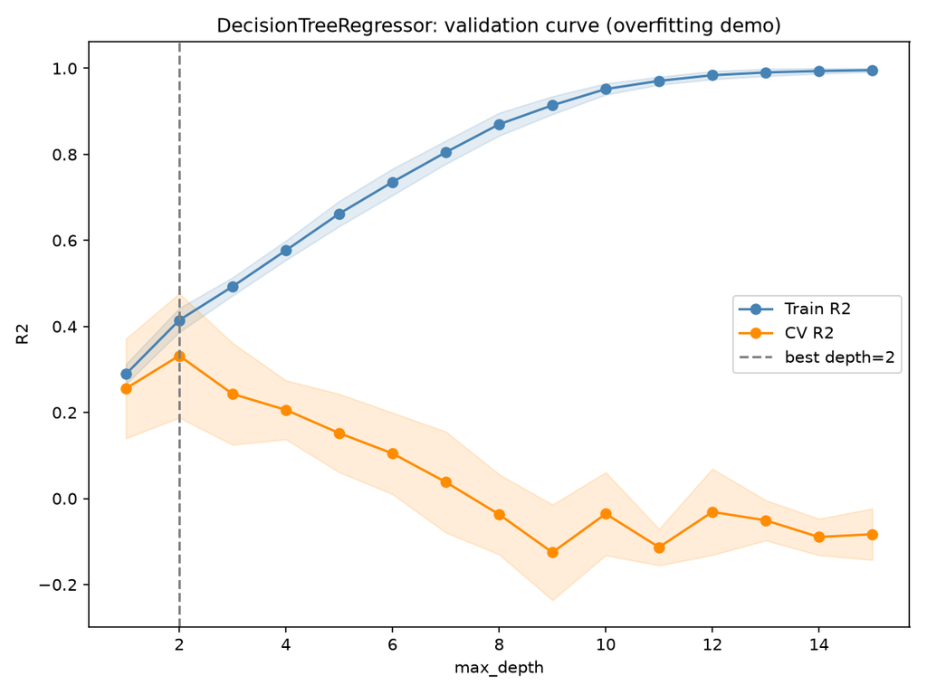

(a) Left: validation curve showing the Decision Tree overfitting past depth 2. Right: predicted vs. actual duration for all four models on the test set.

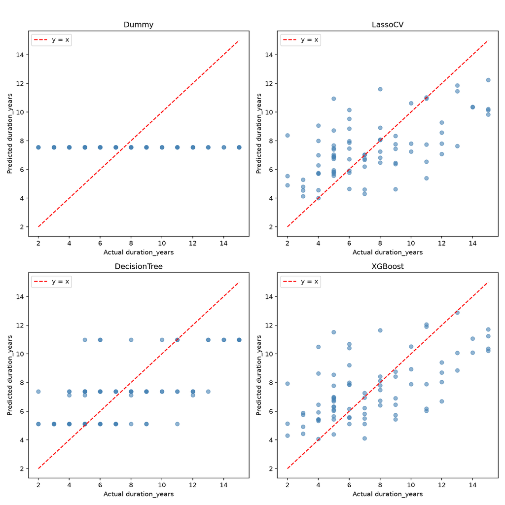

(b)

Figure 2

```python
pd.read_csv(PROJECT_ROOT / "modeling_output" / "regression_leaderboard.csv")
```

|  | model | train_R2 | test_R2 | test_MAE | test_RMSE | R2_gap |
| --- | --- | --- | --- | --- | --- | --- |
| 0 | DecisionTree | 0.409782 | 0.377406 | 2.233481 | 2.722067 | 0.032376 |
| 1 | XGBoost | 0.707268 | 0.366120 | 2.230457 | 2.746628 | 0.341148 |
| 2 | LassoCV | 0.442862 | 0.362124 | 2.235049 | 2.755272 | 0.080738 |
| 3 | Dummy | 0.000000 | -0.001348 | 2.897292 | 3.452143 | 0.001348 |

## Classification Ladder: Early, Typical, or Long-Run?

Same idea, predicting the 3-class bucket instead of an exact number of years.

```python
import classification_ladder

classification_ladder.main()
```

```
DecisionTreeClassifier best max_depth by CV F1-macro: 4 (train=0.693, CV=0.565)
XGBClassifier best params: {'model__colsample_bytree': np.float64(0.8185450708005443), 'model__learning_rate': np.float64(0.2787310710802003), 'model__max_depth': 4, 'model__n_estimators': 97, 'model__subsample': np.float64(0.7979622306417505)}
XGBClassifier best CV F1-macro: 0.592
```

```
=== Classification Leaderboard ===
               model  train_accuracy  test_accuracy  precision_macro  recall_macro  f1_macro  roc_auc_macro_ovr
             XGBoost        0.987768       0.597561         0.604941      0.581786  0.587856           0.746332
        DecisionTree        0.669725       0.548780         0.571685      0.549799  0.558729           0.745029
LogisticRegressionCV        0.614679       0.536585         0.569324      0.529977  0.541510           0.695723
               Dummy        0.403670       0.402439         0.134146      0.333333  0.191304           0.500000
XGBoost: +0.397 F1-macro over Dummy baseline (notable)
DecisionTree: +0.367 F1-macro over Dummy baseline (notable)
LogisticRegressionCV: +0.350 F1-macro over Dummy baseline (notable)

LogisticRegressionCV coefficients saved to classification_logreg_coefficients.csv

Top XGBoost permutation importances (classification, raw input columns):
raised_musd               0.149867
decade_started            0.103110
Sector                    0.037597
big_tech_pressure         0.025201
n_flags_sq                0.013125
No Budget                 0.012687
Niche Limits              0.012407
Acquisition Stagnation    0.010609
Competition               0.010298
Poor Market Fit           0.010188
dtype: float64
```

```python
display(Image(filename=str(PROJECT_ROOT / "modeling_output" / "classification_tree_validation_curve.png")))
display(Image(filename=str(PROJECT_ROOT / "modeling_output" / "classification_confusion_matrices.png")))
```

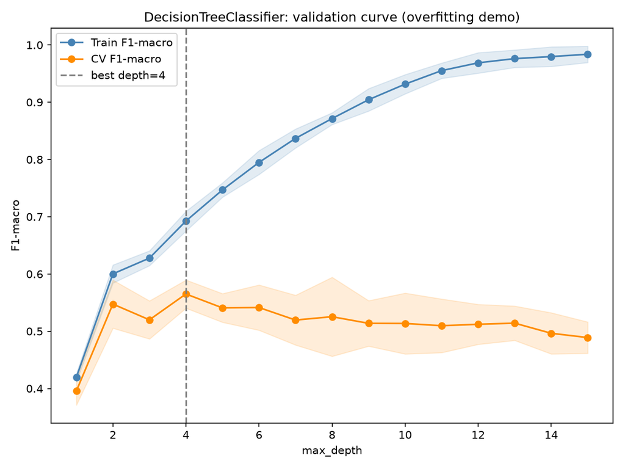

(a) Left: validation curve for the Decision Tree classifier. Right: confusion matrices for all four models on the test set.

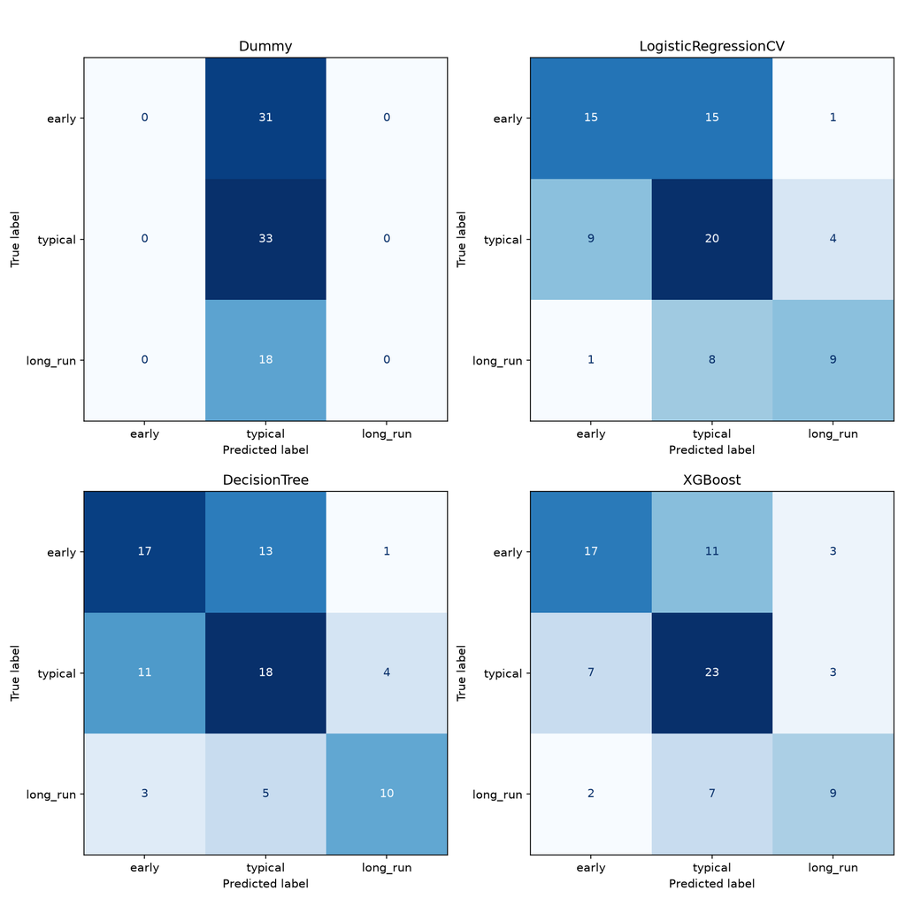

(b)

Figure 3

```python
pd.read_csv(PROJECT_ROOT / "modeling_output" / "classification_leaderboard.csv")
```

|  | model | train_accuracy | test_accuracy | precision_macro | recall_macro | f1_macro | roc_auc_macro_ovr |
| --- | --- | --- | --- | --- | --- | --- | --- |
| 0 | XGBoost | 0.987768 | 0.597561 | 0.604941 | 0.581786 | 0.587856 | 0.746332 |
| 1 | DecisionTree | 0.669725 | 0.548780 | 0.571685 | 0.549799 | 0.558729 | 0.745029 |
| 2 | LogisticRegressionCV | 0.614679 | 0.536585 | 0.569324 | 0.529977 | 0.541510 | 0.695723 |
| 3 | Dummy | 0.403670 | 0.402439 | 0.134146 | 0.333333 | 0.191304 | 0.500000 |

## Honest Evaluation

**XGBoost does not clearly beat the simpler models here.** On the regression task, the Decision Tree’s test R² (0.377) actually edges out XGBoost’s (0.366) outright, while overfitting roughly a tenth as much (a train–test R² gap of 0.032 vs. 0.341) — XGBoost memorizes the training split (train R²=0.707) without that translating into better held-out performance.

On the classification task, XGBoost does post the best test-set numbers (F1=0.588 vs. the Tree’s 0.559), but that edge comes with about 3.2× the overfitting risk (a 0.390 train–test accuracy gap vs. the Tree’s 0.121), and the two are essentially tied on ROC-AUC (0.746 vs 0.745).

## Which Features Matter

```python
print("Regression -- Lasso coefficients (top 8 by magnitude):")
display(pd.read_csv(PROJECT_ROOT / "modeling_output" / "regression_lasso_coefficients.csv").head(8))

print("\nRegression -- XGBoost permutation importance (top 8):")
display(pd.read_csv(PROJECT_ROOT / "modeling_output" / "regression_xgb_permutation_importance.csv").head(8))
```

```
Regression -- Lasso coefficients (top 8 by magnitude):
```

|  | Unnamed: 0 | 0 |
| --- | --- | --- |
| 0 | cat__decade_started_2010s_plus | -2.801365 |
| 1 | num__log_raised_musd | 1.106343 |
| 2 | bin__single_cause_failure | -0.989951 |
| 3 | cat__decade_started_2000s | 0.789675 |
| 4 | bin__Poor Market Fit | -0.701575 |
| 5 | bin__Giants | 0.536362 |
| 6 | cat__Sector_Manufacturing | -0.530259 |
| 7 | num__n_flags_sq | -0.424524 |

```
Regression -- XGBoost permutation importance (top 8):
```

|  | Unnamed: 0 | 0 |
| --- | --- | --- |
| 0 | decade_started | 0.451816 |
| 1 | raised_musd | 0.236141 |
| 2 | Sector | 0.037267 |
| 3 | No Budget | 0.014393 |
| 4 | Poor Market Fit | 0.013040 |
| 5 | Trend Shifts | 0.007298 |
| 6 | big_tech_pressure | 0.005120 |
| 7 | Competition | 0.003035 |

```python
print("Classification -- XGBoost permutation importance (top 8):")
pd.read_csv(PROJECT_ROOT / "modeling_output" / "classification_xgb_permutation_importance.csv").head(8)
```

```
Classification -- XGBoost permutation importance (top 8):
```

|  | Unnamed: 0 | 0 |
| --- | --- | --- |
| 0 | raised_musd | 0.149867 |
| 1 | decade_started | 0.103110 |
| 2 | Sector | 0.037597 |
| 3 | big_tech_pressure | 0.025201 |
| 4 | n_flags_sq | 0.013125 |
| 5 | No Budget | 0.012687 |
| 6 | Niche Limits | 0.012407 |
| 7 | Acquisition Stagnation | 0.010609 |

Across **both** tasks and **both** the linear and tree-based models, two features consistently dominate: **how much a company raised**, and **when it was founded** — companies founded in the 2010s and later, and those that raised less, tend to show shorter observed durations. This matters more than any single failure reason cited. Among the reason flags, only `No Budget`, `Poor Market Fit`, and `Big Tech pressure` show up as important in *both* model types — the others (like `single_cause_failure` and `Giants`) carry large coefficients in the linear models but wash out under the tree model’s permutation test, suggesting they’re collinear with funding/founding-era rather than independent signal.

## Business Interpretation and Recommendations

**What these results mean:** this model explains variation in *observed* duration among startups that already failed. It is **not** a forecast of how long a currently-operating company will last — the failure-reason flags it’s trained on are hindsight labels, only knowable after the outcome was already determined. Repositioning it as a forward-looking survival predictor would misrepresent what it was trained on.

**What we would not trust this model to do:**

1. Predict the remaining runway of an active, non-failed company.
2. Generalize to sectors thin on data — Food/services has only 26 rows total.
3. Extrapolate past the observed funding range (the largest raise in this dataset is $3.5B).
4. Support causal claims — “Poor Market Fit *causes* shorter duration” is not established; only that companies labeled this way tended to have shorter observed duration in this sample.

## Try It Yourself

The Decision Tree models trained here are deployed behind a live web app — enter a hypothetical startup’s details and get a real-time prediction, or browse the same leaderboard shown above:

**https://startup-failure-prediction.vercel.app**

See the repository README for how to reproduce this report and the rest of the project locally.